# Exam 2

Jules Pellin

2026-05-28

# Question 1 - Add a year column using lubridate

```r
library(tidyverse)
library(lubridate)

# Load exam input file
dat <- read.csv("Exam 2 Input File.csv")

# Examine the data
head(dat)
```

```
##   X YYYY.MM.DD.DOY.    yield irrigation_demand county_name       crop
## 1 1 1980-08-27(240) 15147.19          421.8288    Okanogan Corn_grain
## 2 2 1981-08-21(233) 15926.39          427.0740    Okanogan Corn_grain
## 3 3 1982-08-16(228) 13489.79          363.3833    Okanogan Corn_grain
## 4 4 1983-08-19(231) 15263.74          382.2921    Okanogan Corn_grain
## 5 5 1984-08-22(235) 13779.91          391.8027    Okanogan Corn_grain
## 6 6 1985-08-04(216) 13920.45          445.9654    Okanogan Corn_grain
##               lat_lon
## 1 48.15625N119.71875W
## 2 48.15625N119.71875W
## 3 48.15625N119.71875W
## 4 48.15625N119.71875W
## 5 48.15625N119.71875W
## 6 48.15625N119.71875W
```

```r
str(dat)
```

```
## 'data.frame':    474 obs. of  7 variables:
##  $ X                : int  1 2 3 4 5 6 7 8 9 10 ...
##  $ YYYY.MM.DD.DOY.  : chr  "1980-08-27(240)" "1981-08-21(233)" "1982-08-16(228)" "1983-08-19(231)" ...
##  $ yield            : num  15147 15926 13490 15264 13780 ...
##  $ irrigation_demand: num  422 427 363 382 392 ...
##  $ county_name      : chr  "Okanogan" "Okanogan" "Okanogan" "Okanogan" ...
##  $ crop             : chr  "Corn_grain" "Corn_grain" "Corn_grain" "Corn_grain" ...
##  $ lat_lon          : chr  "48.15625N119.71875W" "48.15625N119.71875W" "48.15625N119.71875W" "48.15625N119.71875W" ...
```

```r
# The date column is formatted as "1980-08-27(240)" — strip the (DOY) part first
dat$date_clean <- gsub("\\(.*\\)", "", dat$YYYY.MM.DD.DOY.)

# Parse cleaned date and extract year
dat$year <- year(ymd(dat$date_clean))

# Verify
head(dat[, c("YYYY.MM.DD.DOY.", "date_clean", "year")])
```

```
##   YYYY.MM.DD.DOY. date_clean year
## 1 1980-08-27(240) 1980-08-27 1980
## 2 1981-08-21(233) 1981-08-21 1981
## 3 1982-08-16(228) 1982-08-16 1982
## 4 1983-08-19(231) 1983-08-19 1983
## 5 1984-08-22(235) 1984-08-22 1984
## 6 1985-08-04(216) 1985-08-04 1985
```

# Question 2 - Filter to ≤90th percentile by crop-county combination

```r
# Calculate 90th percentile threshold per crop-county group
# then filter out rows above it
dat_filtered <- dat %>%
  group_by(county_name, crop) %>%
  filter(irrigation_demand <= quantile(irrigation_demand, probs = 0.90)) %>%
  ungroup()

# Check how many rows were removed
nrow(dat)
```

```
## [1] 474
```

```r
nrow(dat_filtered)
```

```
## [1] 430
```

```r
# Create irrigation demand CSV — keep county, crop, lat_lon, year, irrigation_demand
irr <- dat_filtered %>%
  select(county_name, crop, lat_lon, year, irrigation_demand)

# Create yield CSV — keep county, crop, lat_lon, year, yield
yld <- dat_filtered %>%
  select(county_name, crop, lat_lon, year, yield)

# Save both as CSV files
write.csv(irr, "irrigation_demand.csv", row.names = FALSE)
write.csv(yld, "yield.csv", row.names = FALSE)

cat("Files saved successfully\n")
```

```
## Files saved successfully
```

# Question 3 - Left, Right, and Full joins

```r
# Read the two CSV files back in
irr2 <- read.csv("irrigation_demand.csv")
yld2 <- read.csv("yield.csv")

# Left join — keeps all irrigation rows, NAs for non-matching yield rows
left_join_df <- merge(irr2, yld2,
                      by = c("county_name", "crop", "lat_lon", "year"),
                      all.x = TRUE)

# Right join — keeps all yield rows, NAs for non-matching irrigation rows
right_join_df <- merge(irr2, yld2,
                       by = c("county_name", "crop", "lat_lon", "year"),
                       all.y = TRUE)

# Full join — keeps everything from both files
full_join_df <- merge(irr2, yld2,
                      by = c("county_name", "crop", "lat_lon", "year"),
                      all = TRUE)

# Compare row counts
cat("Left join rows:", nrow(left_join_df), "\n")
```

```
## Left join rows: 430
```

```r
cat("Right join rows:", nrow(right_join_df), "\n")
```

```
## Right join rows: 430
```

```r
cat("Full join rows:", nrow(full_join_df), "\n")
```

```
## Full join rows: 430
```

All three joins return 430 rows because both CSV files came from the same filtered dataset, just with different columns selected. Since every key combination exists in both files, there are no non-matching rows either way. The row counts would only differ if the two files had different key combinations.

# Question 4 - Completeness check of full join

```r
# Create a complete grid of ALL expected county-crop-year combinations
all_combos <- expand.grid(
  county_name = unique(full_join_df$county_name),
  crop        = unique(full_join_df$crop),
  year        = unique(full_join_df$year)
)

cat("Expected rows (complete grid):", nrow(all_combos), "\n")
```

```
## Expected rows (complete grid): 240
```

```r
cat("Actual rows in full join:", nrow(full_join_df), "\n")
```

```
## Actual rows in full join: 430
```

```r
cat("Missing rows (implicit NAs):", nrow(all_combos) - nrow(full_join_df), "\n")
```

```
## Missing rows (implicit NAs): -190
```

```r
# Check for explicit NAs (rows exist but irrigation_demand is NA)
cat("Explicit NAs in irrigation_demand:", sum(is.na(full_join_df$irrigation_demand)), "\n")
```

```
## Explicit NAs in irrigation_demand: 0
```

```r
# Use crossing() to build a proper complete grid
# First get all unique location-crop pairs that actually exist
location_crop_pairs <- full_join_df %>%
  select(county_name, crop, lat_lon) %>%
  distinct()

# Cross with all unique years
all_combos <- crossing(location_crop_pairs, year = unique(full_join_df$year))

cat("Expected rows (complete grid):", nrow(all_combos), "\n")
```

```
## Expected rows (complete grid): 480
```

```r
cat("Actual rows in full join:", nrow(full_join_df), "\n")
```

```
## Actual rows in full join: 430
```

```r
# Find implicit NAs — combinations completely absent from the data
implicit_missing <- anti_join(all_combos, full_join_df,
                              by = c("county_name", "crop", "lat_lon", "year"))

cat("Missing rows (implicit NAs):", nrow(implicit_missing), "\n")
```

```
## Missing rows (implicit NAs): 50
```

```r
# Check explicit NAs
cat("Explicit NAs in irrigation_demand:", sum(is.na(full_join_df$irrigation_demand)), "\n")
```

```
## Explicit NAs in irrigation_demand: 0
```

The full join data is not complete for all years across all groups. Out of 480 expected county-crop-year combinations, only 430 are present, leaving 50 missing rows. All 50 are implicit NAs, meaning the rows are completely absent from the data rather than present with NA values. This likely happened because the 90th percentile filtering in Q2 removed enough rows from certain county-crop groups that entire years dropped out entirely. There are zero explicit NAs in the irrigation demand column.

# Question 5 - Fill implicit NAs with county-crop average

```r
# Add missing rows to the full join with NA for irrigation_demand and yield
complete_df <- full_join_df %>%
  full_join(implicit_missing, by = c("county_name", "crop", "lat_lon", "year"))

# Fill irrigation_demand NAs with county-crop group average
complete_df <- complete_df %>%
  group_by(county_name, crop) %>%
  mutate(irrigation_demand_filled = ifelse(
    is.na(irrigation_demand),
    mean(irrigation_demand, na.rm = TRUE),
    irrigation_demand
  )) %>%
  ungroup()

cat("Rows in complete dataset:", nrow(complete_df), "\n")
```

```
## Rows in complete dataset: 480
```

```r
cat("NAs remaining after fill:", sum(is.na(complete_df$irrigation_demand_filled)), "\n")
```

```
## NAs remaining after fill: 0
```

# Question 6 - Missing rows data frame and comparison plot

```r
# Create data frame of only the originally missing rows
# with both original (NA) and filled irrigation demand values
missing_df <- complete_df %>%
  filter(is.na(irrigation_demand)) %>%
  select(county_name, crop, lat_lon, year,
         irrigation_demand_original = irrigation_demand,
         irrigation_demand_filled)

cat("Missing rows data frame:", nrow(missing_df), "rows\n")
```

```
## Missing rows data frame: 50 rows
```

```r
head(missing_df)
```

```
## # A tibble: 6 × 6
##   county_name crop   lat_lon  year irrigation_demand_or…¹ irrigation_demand_fi…²
##   <chr>       <chr>  <chr>   <int>                  <dbl>                  <dbl>
## 1 Okanogan    Corn_… 48.156…  1981                     NA                   376.
## 2 Okanogan    Corn_… 48.156…  1985                     NA                   376.
## 3 Okanogan    Corn_… 48.156…  1988                     NA                   376.
## 4 Okanogan    Corn_… 48.156…  2008                     NA                   376.
## 5 Okanogan    Corn_… 48.156…  2011                     NA                   376.
## 6 Okanogan    Corn_… 48.156…  2018                     NA                   376.
## # ℹ abbreviated names: ¹irrigation_demand_original, ²irrigation_demand_filled
```

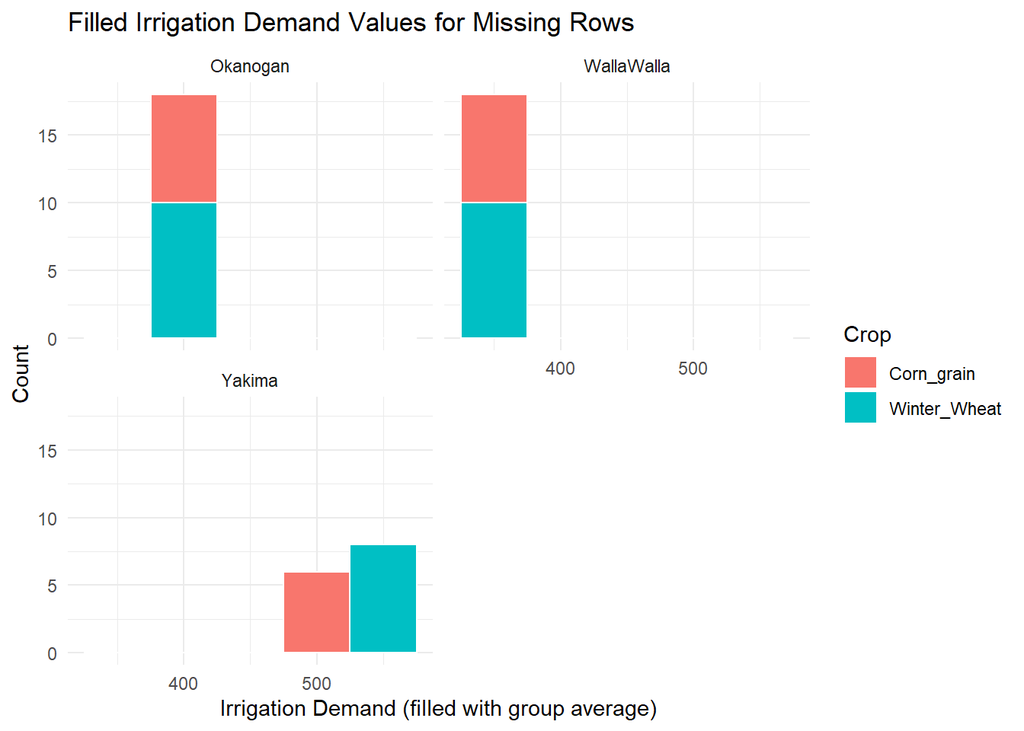

```r
# Plot: compare filled values across county-crop groups
ggplot(missing_df, aes(x = irrigation_demand_filled, fill = crop)) +
  geom_histogram(binwidth = 50, color = "white") +
  facet_wrap(~ county_name, ncol = 2) +
  labs(title = "Filled Irrigation Demand Values for Missing Rows",
       x = "Irrigation Demand (filled with group average)",
       y = "Count",
       fill = "Crop") +
  theme_minimal()
```